# A4 -Análisis de varianza y repaso del curso

Autor: Eduardo Mora González

Enero 2023

# 1 Preprocesado

Carga del archivo

```r
datos <- read_delim("C:/Users/eduar/Dropbox/ESTUDIOS/Estadística avanzada/PRACTICA FINAL/Fumadores.csv",
    delim = ";", escape_double = FALSE, trim_ws = TRUE)
```

Y mostrar los tipos de datos y estaditica básica

```r
str(datos)
```

```
## spc_tbl_ [253 x 4] (S3: spec_tbl_df/tbl_df/tbl/data.frame)
##  $ AE    : chr [1:253] "1.871878" "1.91312" "2.58114" "2.17827" ...
##  $ Tipo  : chr [1:253] "NF" "NF" "NF" "NF" ...
##  $ genero: chr [1:253] "M" "F" "M" "F" ...
##  $ edad  : num [1:253] 54 60 40 55 59 63 62 62 26 48 ...
##  - attr(*, "spec")=
##   .. cols(
##   ..   AE = col_character(),
##   ..   Tipo = col_character(),
##   ..   genero = col_character(),
##   ..   edad = col_double()
##   .. )
##  - attr(*, "problems")=<externalptr>
```

## 1.1 Comprobación y transformación de la variable AE

Como vemos, la variable AE nos la ha identificado como tipo cadena, se va comprobar si existe alguna coma, y se va a pasar a numérico.

```r
#corregimos por si existe alguna coma
datos$AE <- gsub("\\,","\\.", datos$AE)

#Pasamos a numérico
datos$AE<- as.numeric(datos$AE)
```

Y vemos la estadísticas de todos los datos

```r
summary(datos$AE)
```

```
##    Min. 1st Qu.  Median    Mean 3rd Qu.    Max.
##  0.2649  1.1618  1.5344  1.5493  1.8824  3.6226
```

Vemos que los datos están dentro del rango, por lo que no se encuentran inconsistencias

## 1.2 Comprobación y transformación de la variable Edad

```r
summary(datos$edad)
```

```
##    Min. 1st Qu.  Median    Mean 3rd Qu.    Max.
##   17.00   43.00   50.00   49.76   57.00   78.00
```

Vemos que los datos están dentro del rango, por lo que no se encuentran inconsistencias

## 1.3 Comprobación y transformación de la variable Genero

Pasamos todos los datos a mayusculas antes de hacer las comprobaciones

```r
datos$genero <- toupper(datos$genero)
```

Comprobamos que existan solo dos tipos de género

```r
fem.idx <- which(datos$genero=="F")
mas.idx <- which( datos$genero=="M")
suma <- length(fem.idx) + length(mas.idx)
cat("La suma de todos los datos son:",suma)
```

```
## La suma de todos los datos son: 253
```

Vemos que existen el mismo numero de observaciones que en la estructura del dataframe obtenida al inicio, por lo que no existe inconsistencias en la variable género.

## 1.4 Comprobación y transformación de la variable Tipo

Pasamos todos los datos a mayusculas antes de hacer las comprobaciones

```r
datos$Tipo <- toupper(datos$Tipo)
```

Para esta variable, vemos que hay varios tipos, por lo que se obtendrá el índice de cada tipo para hacer las comprobaciones de los tipos con condiciones

```r
NF.idx <- which(datos$Tipo=="NF")
FP.idx <- which(datos$Tipo=="FP")
NI.idx <- which(datos$Tipo=="NI")
FL.idx <- which(datos$Tipo=="FL")
FM.idx <- which(datos$Tipo=="FM")
FI.idx <- which(datos$Tipo=="FI")

#Comprobamos la suma de todos los registros
suma <- length(NF.idx) + length(FP.idx) + length(NI.idx) + length(FL.idx) + length(FM.idx) + length(FI.idx)
cat("La suma de todos los datos son:",suma)
```

```
## La suma de todos los datos son: 253
```

Vemos que existen el mismo numero de observaciones que en la estructura del dataframe obtenida al inicio.

Obtenemos la edad mas pequeña y le sumamos 20 años, para las siguientes comprobaciones

```r
min_edad<- min(datos$edad) + 20
cat("La edad es:",min(datos$edad), "y al sumarle 20 se ha quedado en:", min_edad)
```

```
## La edad es: 17 y al sumarle 20 se ha quedado en: 37
```

### 1.4.1 TIPO Fumadores ligeros (FL)

```r
FL.Edad.idx <- which((datos$Tipo=="FL") & (datos$edad < min_edad))
cat ("Hay", length(FL.Edad.idx), "que NO cumple la condicion")
```

```
## Hay 4 que NO cumple la condicion
```

Para estos 4 valores, se va a optar por cambiarle el tipo a otros que cumplan las condiciones.

```r
datos$Tipo[FL.Edad.idx[1]] <- "NF"
datos$Tipo[FL.Edad.idx[2]] <- "NI"
datos$Tipo[FL.Edad.idx[3]] <- "FP"
datos$Tipo[FL.Edad.idx[4]] <- "NF"
```

Y comprobamos

```r
FL.Edad.idx <- which((datos$Tipo=="FL") & (datos$edad < min_edad))
cat ("Ahora hay", length(FL.Edad.idx), "que NO cumple la condicion")
```

```
## Ahora hay 0 que NO cumple la condicion
```

### 1.4.2 TIPO Fumadores moderados (FM)

```r
FM.Edad.idx <- which((datos$Tipo=="FM") & (datos$edad < min_edad))
cat ("Hay", length(FM.Edad.idx), "que NO cumple la condicion")
```

```
## Hay 2 que NO cumple la condicion
```

Al ser solo dos, se va a aumentar la edad en 20 años para que se cumpla la condición

```r
datos$edad[FM.Edad.idx[1]] <- datos$edad[FM.Edad.idx[1]] + 20
datos$edad[FM.Edad.idx[2]] <- datos$edad[FM.Edad.idx[2]] + 20
```

Y comprobamos

```r
FM.Edad.idx <- which((datos$Tipo=="FM") & (datos$edad < min_edad))
cat ("Ahora hay", length(FM.Edad.idx), "que NO cumple la condicion")
```

```
## Ahora hay 0 que NO cumple la condicion
```

### 1.4.3 TIPO Fumadores intensivos (FI)

```r
FI.Edad.idx <- which((datos$Tipo=="FI") & (datos$edad < min_edad))
cat ("Hay", length(FI.Edad.idx), "que NO cumple la condicion")
```

```
## Hay 5 que NO cumple la condicion
```

Para estos 5 valores, se va a optar por cambiarle el tipo a otros que cumplan las condiciones, y al estar dentro de los que fuman intensamente, se ha descartado el tipo NF.

```r
datos$Tipo[FI.Edad.idx[1]] <- "FP"
datos$Tipo[FI.Edad.idx[2]] <- "NI"
datos$Tipo[FI.Edad.idx[3]] <- "FP"
datos$Tipo[FI.Edad.idx[4]] <- "NI"
datos$Tipo[FI.Edad.idx[5]] <- "FP"
```

Y comprobamos

```r
FI.Edad.idx <- which((datos$Tipo=="FI") & (datos$edad < min_edad))
cat ("Ahora hay", length(FI.Edad.idx), "que NO cumple la condicion")
```

```
## Ahora hay 0 que NO cumple la condicion
```

# 2 Análisis descriptivo de la muestra

## 2.1 Capacidad pulmonar y género

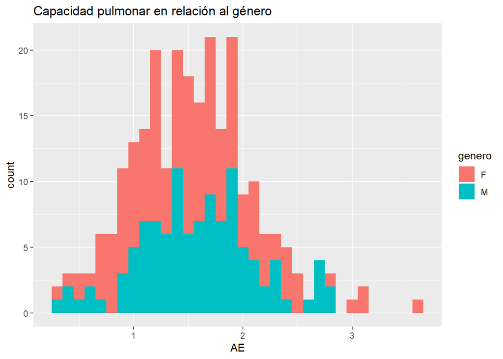

```r
ggplot(data = datos ,aes(x=AE,fill=genero))+geom_histogram(binwidth =0.1)+ggtitle("Capacidad pulmonar en relación al género")
```

A primera vista nos damos cuenta de que hay más registros de mujeres que de hombres. Por otro lado, los datos tienen una distribución normal mirándolo de una manera visual, aunque el grueso de los datos esta entre 0,9 y 2. A nivel de comparativa, los picos con más números de registros coinciden en parte en los dos géneros. Por otro lado, el rango de datos de las mujeres es mayor que la de los hombres.

## 2.2 Capacidad pulmonar y edad

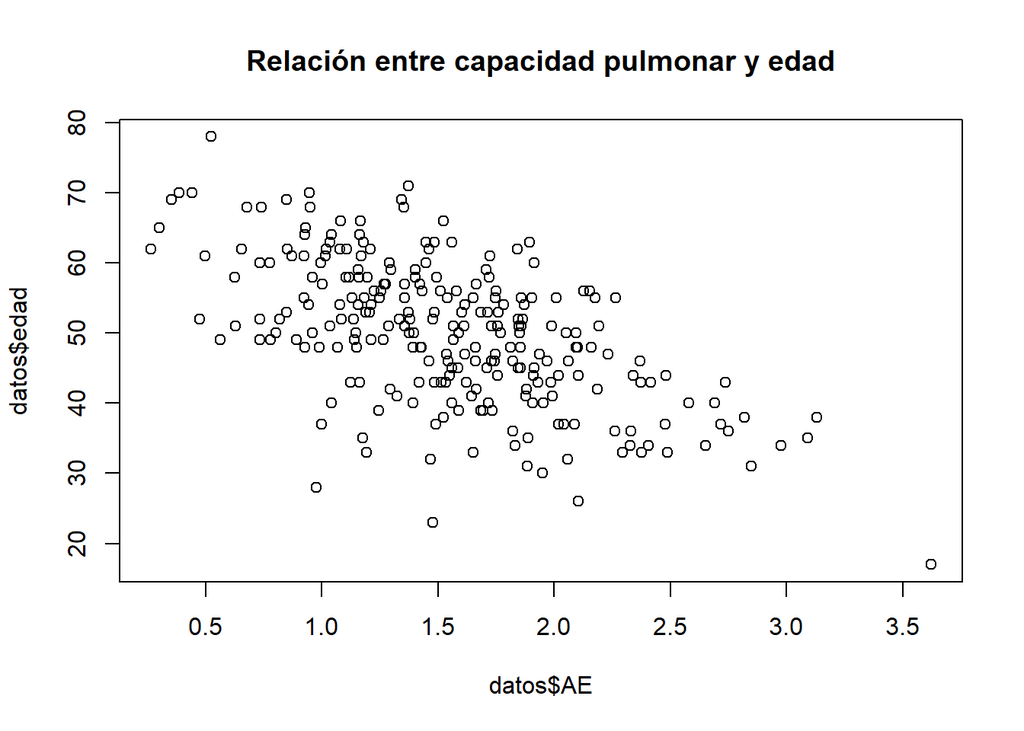

```r
plot(x = datos$AE, y = datos$edad, main="Relación entre capacidad pulmonar y edad")
```

Nos damos cuenta de que el mayor número de datos se encuentra entre los pacientes de 35 a 65 años. Por otro lado, la capacidad pulmonar de los pacientes se encuentra mayormente entre 1 y 2, ya que es donde se encuentra el mayor número de registros.

## 2.3 Tipos de fumadores y capacidad pulmonar

```r
# Tabla resumen de los datos
resumen <- datos %>% group_by(Tipo) %>% summarize(Media_Tipo = mean(AE),Personas_Tipo = length(AE)); print(resumen)
```

```
## # A tibble: 6 x 3
##   Tipo  Media_Tipo Personas_Tipo
##   <chr>      <dbl>         <int>
## 1 FI          1.19            36
## 2 FL          1.53            37
## 3 FM          1.16            39
## 4 FP          1.62            44
## 5 NF          1.99            52
## 6 NI          1.61            45
```

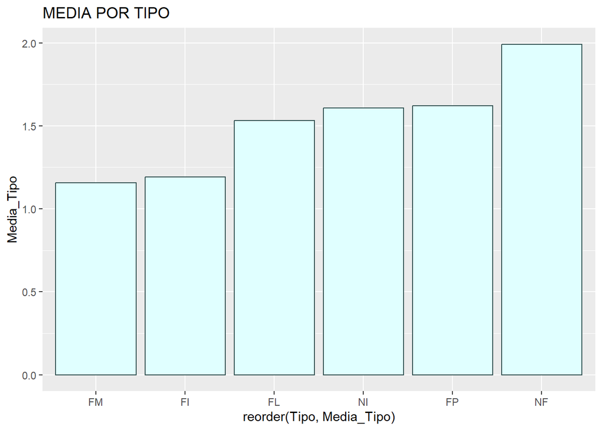

```r
#Histograma de la media por Tipo
ggplot(resumen, aes(x = reorder(Tipo, Media_Tipo), y = Media_Tipo)) + geom_col(color='#2F4F4F', fill='#E0FFFF') +
ggtitle("MEDIA POR TIPO")
```

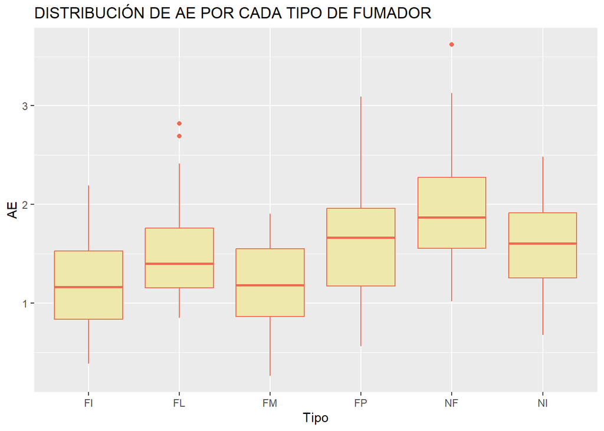

```r
ggplot(datos, aes(x = Tipo, y = AE)) + geom_boxplot(color='#EE6A50', fill='#EEE8AA')+
ggtitle("DISTRIBUCIÓN DE AE POR CADA TIPO DE FUMADOR")
```

A nivel media del tipo, vemos que los No Fumadores o NF tienen mejor capacidad pulmonar, mientras que los Fumadores Moderados o FM son los que tienen peor. Por otro lado, los fumadores que inhalan el humo (FL, FM, FI) son los que tienen peor capacidad tienen.

# 3 Intervalo de confianza de la capacidad pulmonar

## 3.1 Supuestos

Los supuestos para el intervalo de confianza son si se puede suponer una distribución normal de los datos, y como se ha comprobado en el apartado anterior los datos en parte tienen una distribución normal

## 3.2 División de los datos

```r
#Obtenemos los Indices de las mujeres
idx.mujer <- which(datos$genero == 'F')

#Creamos dos conjunto de datos depende del genero
datos_mujeres <- datos[idx.mujer,]
datos_hombres <- datos[-idx.mujer,]
```

Los supuestos para el intervalo de confianza son si se puede suponer una distribución normal de los datos, y como se ha comprobado en el apartado anterior los datos tienen una distribución normal.

## 3.3 Función de cálculo del intervalo de confianza

Para realizar el cálculo, se va a crear una función para el cálculo. Dicha función se ha obtenido de practicas anteriores de la asignatura.

```r
IC <- function( x, NC ){
  n <- length(x)
  alfa <- 1-(NC/100)
  sd <- sd(x)
  SE <- sd / sqrt(n)
  t <- qt( alfa/2, df=n-1, lower.tail=FALSE )
  L <- mean(x) - t*SE
  U <- mean(x) + t*SE
  return (c(L, U))
}
```

## 3.4 Intervalo de confianza

```r
IC_Mujeres.AE.95<-IC(datos_mujeres$AE, 95); IC_Mujeres.AE.95
```

```
## [1] 1.428428 1.618132
```

```r
IC_Hombres.AE.95<-IC(datos_hombres$AE, 95); IC_Hombres.AE.95
```

```
## [1] 1.482301 1.685224
```

## 3.5 Comprobación

```r
t.test(datos_mujeres$AE, conf.level=0.95)
```

```
##
##  One Sample t-test
##
## data:  datos_mujeres$AE
## t = 31.745, df = 143, p-value < 2.2e-16
## alternative hypothesis: true mean is not equal to 0
## 95 percent confidence interval:
##  1.428428 1.618132
## sample estimates:
## mean of x
##   1.52328
```

```r
t.test(datos_hombres$AE, conf.level=0.95)
```

```
##
##  One Sample t-test
##
## data:  datos_hombres$AE
## t = 30.941, df = 108, p-value < 2.2e-16
## alternative hypothesis: true mean is not equal to 0
## 95 percent confidence interval:
##  1.482301 1.685224
## sample estimates:
## mean of x
##  1.583762
```

Vemos que los datos coinciden tanto en la salida de la función como la del test

## 3.6 Interpretación

El intervalo de confianza del 95% de la media poblacional de AE de las mujeres es (1.428428, 1.618132), esto quiere decir que, si se sacan diferentes muestras de la población, el 95% de los intervalos calculados contienen el valor de la media poblacional.

El intervalo de confianza del 95% de la media poblacional de AE de los hombres es (1.482301, 1.685224), esto quiere decir que, si se sacan diferentes muestras de la población, el 95% de los intervalos calculados contienen el valor de la media poblacional.

## 3.7 ¿se observan diferencias significativas en la capacidad pulmonar de mujeres y hombres?

No se encuentran diferencias significativa, ya que la salida de los IC tantos de los hombres como de las mujeres son muy similares.

# 4 Diferencias en capacidad pulmonar entre mujeres y hombres

## 4.1 Hipótesis

H0 : µAEMujer = µAEHombre

H1 : µAEMujer != µAEHombre

## 4.2 Contraste

Es un test de dos muestras sobre la media con varianzas desconocidas. Por el teorema del límite central, podemos asumir normalidad. Comprobamos igualdad de varianzas:

```r
var.test( datos_hombres$AE, datos_mujeres$AE )
```

```
##
##  F test to compare two variances
##
## data:  datos_hombres$AE and datos_mujeres$AE
## F = 0.86133, num df = 108, denom df = 143, p-value = 0.4152
## alternative hypothesis: true ratio of variances is not equal to 1
## 95 percent confidence interval:
##  0.6066144 1.2339167
## sample estimates:
## ratio of variances
##           0.861326
```

El resultado del test no muestra diferencias significativas entre varianzas. Por tanto, aplicaremos un test de dos muestras independientes sobre la media con varianzas desconocidas iguales. El test es bilateral.

## 4.3 Función de cálculo

Para realizar el cálculo, se va a crear una función para el cálculo. Dicha función se ha obtenido de practicas anteriores de la asignatura.

```r
funcion_contraste_medias <- function( x1, x2, CL=0.95, Var_Igual=TRUE, metodo_calculo="two.sided" ){

  media_1<-mean(x1)
  length_1<-length(x1)
  sd1<-sd(x1)

  media_2<-mean(x2)
  length_2<-length(x2)
  sd2<-sd(x2)


  if (Var_Igual==TRUE){

      raiz <-sqrt( ((length_1-1)*sd1^2 + (length_2-1)*sd2^2 )/(length_1+length_2-2) )
      Sb <- raiz*sqrt(1/length_1 + 1/length_2)
      df<-(length_1 - 1) + (length_2 - 1)

  }else{

      Sb <- sqrt( sd1^2/length_1 + sd2^2/length_2 )
      denominador <- ( (sd1^2/length_1)^2/(length_1-1) + (sd2^2/length_2)^2/(length_2-1))
      df <- ( (sd1^2/length_1 + sd2^2/length_2)^2 ) / denominador

  }

  alfa <- (1-CL)
  t<- (media_1-media_2) / Sb


  if (metodo_calculo=="two.sided"){

      tcritical <- qt( alfa/2, df, lower.tail=FALSE )
      pvalue<-pt( abs(t), df, lower.tail=FALSE )*2

  }

  if (metodo_calculo=="greater"){

      tcritical <- qt( alfa, df, lower.tail=FALSE )
      pvalue<-pt( t, df, lower.tail=FALSE )

  }

  if (metodo_calculo=="less"){

      tcritical <- qt( alfa, df, lower.tail=TRUE )
      pvalue<-pt( t, df, lower.tail=TRUE )

  }


  resultados <-data.frame(t,tcritical,pvalue)

  return (resultados)

}
```

## 4.4 Cálculos

```r
#Uso funcion implementada
funcion_contraste_medias( datos_hombres$AE, datos_mujeres$AE , CL=0.95, Var_Igual=TRUE, metodo_calculo = "two.sided")
```

```
##           t tcritical    pvalue
## 1 0.8531624   1.96946 0.3943827
```

```r
#Validación de la función
t.test(datos_hombres$AE, datos_mujeres$AE , var.equal=TRUE, conf.level = 0.95, alternative = "two.sided")
```

```
##
##  Two Sample t-test
##
## data:  datos_hombres$AE and datos_mujeres$AE
## t = 0.85316, df = 251, p-value = 0.3944
## alternative hypothesis: true difference in means is not equal to 0
## 95 percent confidence interval:
##  -0.07913636  0.20010078
## sample estimates:
## mean of x mean of y
##  1.583762  1.523280
```

## 4.5 Interpretación

El valor crítico para un nivel de confianza del 95% es 1,96946 y el valor observado es 0,85316. Por tanto, nos encontramos en la zona de aceptación de la hipótesis nula. Lo mismo se observa con el valor p, que da un valor de 0,3944, y por tanto, superior a alfa=0,05.

Concluimos que la capacidad pulmonar de los hombres no es distinta a la de las mujeres con un nivel de confianza del 95%.

# 5 Diferencias en la capacidad pulmonar entre Fumadores y No Fumadores

## 5.1 Hipótesis

H0 : µAEFumadores = µAENoFumadores

H1 : µAEFumadores < µAENoFumadores

## 5.2 Preparación de los datos

```r
#Obtenemos los indices
No.fumadores.idx <- which((datos$Tipo=="NF") | (datos$Tipo=="FP"))

#Dividimos los datos
datos_fumadores <- datos$AE[-No.fumadores.idx]
datos_No_fumadores<- datos$AE[No.fumadores.idx]
```

## 5.3 Contraste

Es un test de dos muestras sobre la media con varianzas desconocidas. Por el teorema del límite central, podemos asumir normalidad. Comprobamos igualdad de varianzas:

```r
var.test(datos_fumadores,datos_No_fumadores)
```

```
##
##  F test to compare two variances
##
## data:  datos_fumadores and datos_No_fumadores
## F = 0.82798, num df = 156, denom df = 95, p-value = 0.2957
## alternative hypothesis: true ratio of variances is not equal to 1
## 95 percent confidence interval:
##  0.571556 1.180221
## sample estimates:
## ratio of variances
##          0.8279814
```

El resultado del test no muestra diferencias significativas entre varianzas. Por tanto, aplicaremos un test de dos muestras independientes sobre la media con varianzas desconocidas iguales. El test es bilateral.

## 5.4 Cálculos

```r
#Uso funcion implementada
funcion_contraste_medias(datos_fumadores, datos_No_fumadores , CL=0.95, Var_Igual=TRUE, metodo_calculo = "two.sided")
```

```
##          t tcritical       pvalue
## 1 -6.56454   1.96946 2.974497e-10
```

```r
#Validación de la función
t.test(datos_fumadores, datos_No_fumadores, var.equal=TRUE, conf.level = 0.95, alternative = "two.sided")
```

```
##
##  Two Sample t-test
##
## data:  datos_fumadores and datos_No_fumadores
## t = -6.5645, df = 251, p-value = 2.974e-10
## alternative hypothesis: true difference in means is not equal to 0
## 95 percent confidence interval:
##  -0.5711904 -0.3075539
## sample estimates:
## mean of x mean of y
##  1.382619  1.821992
```

## 5.5 Interpretación

El valor crítico para un nivel de confianza del 95% es 1,96946 y el valor observado es -6,5645 Por tanto, nos encontramos en la zona de aceptación de la hipótesis alternativa. Lo mismo se observa con el valor p, que da un valor de 2.974e-10, y por tanto, muy inferior a alfa=0,05.

Concluimos que la capacidad pulmonar de los fumadores es menor de los que no lo son.

# 6 Análisis de regresión lineal

## 6.1 Cálculo

```r
#Creamos el modelo
ModelF <- lm(AE ~ Tipo + edad + genero, data=datos)

#Tabla resumen
summary(ModelF)
```

```
##
## Call:
## lm(formula = AE ~ Tipo + edad + genero, data = datos)
##
## Residuals:
##      Min       1Q   Median       3Q      Max
## -1.23121 -0.21058  0.01509  0.25550  1.10765
##
## Coefficients:
##              Estimate Std. Error t value Pr(>|t|)
## (Intercept)  2.731296   0.143574  19.024  < 2e-16 ***
## TipoFL       0.318361   0.089366   3.562 0.000441 ***
## TipoFM       0.020823   0.088037   0.237 0.813225
## TipoFP       0.293593   0.086298   3.402 0.000781 ***
## TipoNF       0.710239   0.082794   8.578 1.11e-15 ***
## TipoNI       0.306724   0.085523   3.586 0.000405 ***
## edad        -0.029732   0.002425 -12.259  < 2e-16 ***
## generoM      0.002143   0.048987   0.044 0.965142
## ---
## Signif. codes:  0 '***' 0.001 '**' 0.01 '*' 0.05 '.' 0.1 ' ' 1
##
## Residual standard error: 0.3804 on 245 degrees of freedom
## Multiple R-squared:  0.5484, Adjusted R-squared:  0.5355
## F-statistic:  42.5 on 7 and 245 DF,  p-value: < 2.2e-16
```

## 6.2 Interpretación

Como se puede observar, tenemos un coeficiente de determinación del 0,54. Si comparamos la contribución de cada variable con la variable AE nos damos cuenta de:

- Por cada incremento del Tipo FL, se espera que la capacidad pulmonar aumenta en 0,31836.
- Por cada incremento del Tipo FM, se espera que la capacidad pulmonar aumenta en 0,02082.
- Por cada incremento del Tipo FP, se espera que la capacidad pulmonar aumenta en 0,29359.
- Por cada incremento del Tipo NF, se espera que la capacidad pulmonar aumenta en 0,71023.
- Por cada incremento del Tipo NI, se espera que la capacidad pulmonar aumenta en 0,30672.
- Por cada incremento de la edad, se espera que la capacidad pulmonar disminuya en 0,02973.
- Si el género es masculino, se espera que la capacidad pulmonar aumenta en 0,002143.

Por lo que nos damos cuenta de que los No Fumadores son los que más hacen aumentar la capacidad pulmonar, y que, con el aumento de la edad, esta capacidad disminuye.

## 6.3 Bondad de ajuste

Analizamos los residuos del modelo

```r
confint(ModelF)
```

```
##                   2.5 %      97.5 %
## (Intercept)  2.44849812  3.01409369
## TipoFL       0.14233777  0.49438355
## TipoFM      -0.15258343  0.19422895
## TipoFP       0.12361211  0.46357445
## TipoNF       0.54715943  0.87331872
## TipoNI       0.13827076  0.47517771
## edad        -0.03450912 -0.02495463
## generoM     -0.09434700  0.09863312
```

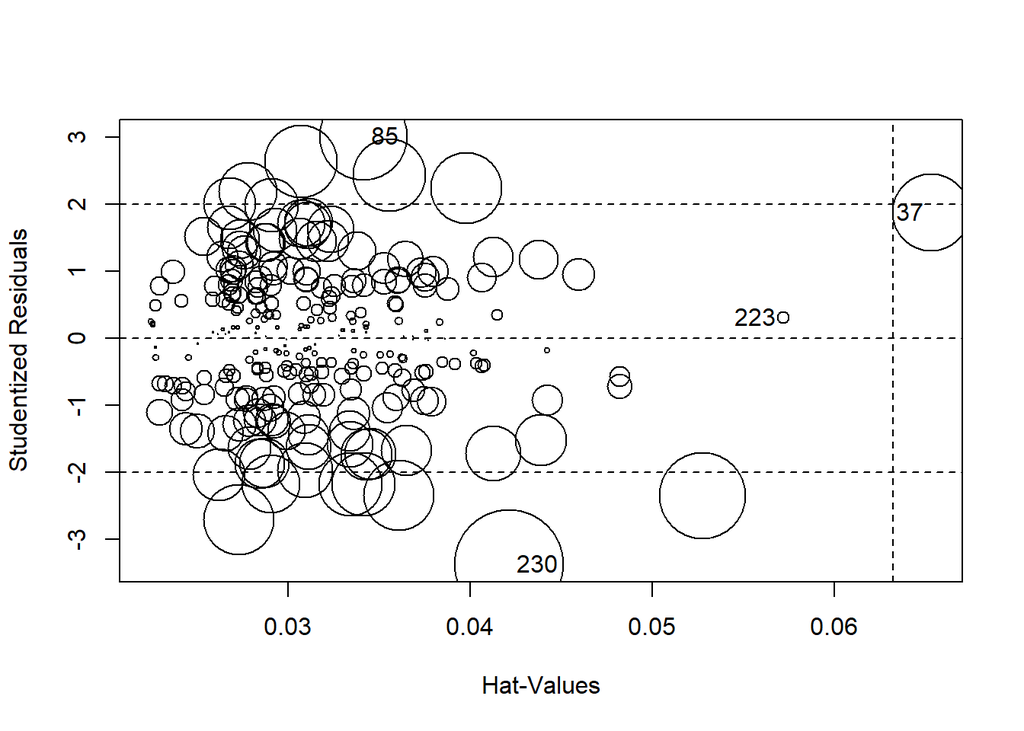

```
##        StudRes        Hat        CookD
## 37   1.8764803 0.06532038 0.0304465202
## 85   3.0114902 0.03416194 0.0388184482
## 223  0.3054411 0.05718950 0.0007100144
## 230 -3.3768166 0.04214751 0.0601642461
```

```r
influencePlot(ModelF)
```

Con este grafico y su salida, nos damos cuenta de que tenemos 4 datos atípicos.

Relación lineal entre los predictores numéricos y la variable dependiente:

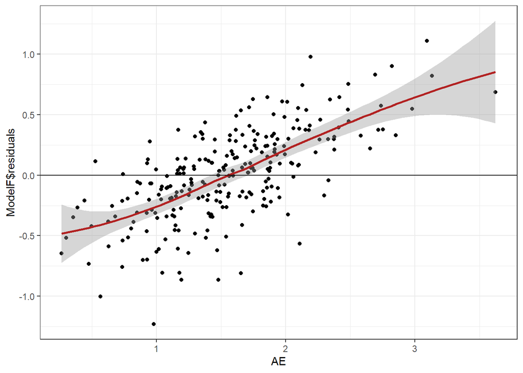

```r
ggplot(data = datos, aes(x = AE, y = ModelF$residuals)) +
geom_point() +
geom_smooth(color = "firebrick") +
geom_hline(yintercept = 0) +
theme_bw()
```

Distribución normal de los residuos:

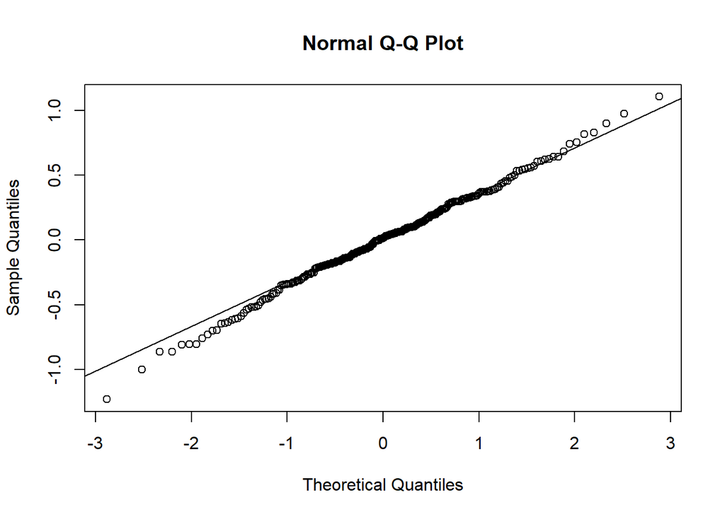

```r
qqnorm(ModelF$residuals)
qqline(ModelF$residuals)
```

La condición de normalidad se satisface.

Variabilidad constante de los residuos:

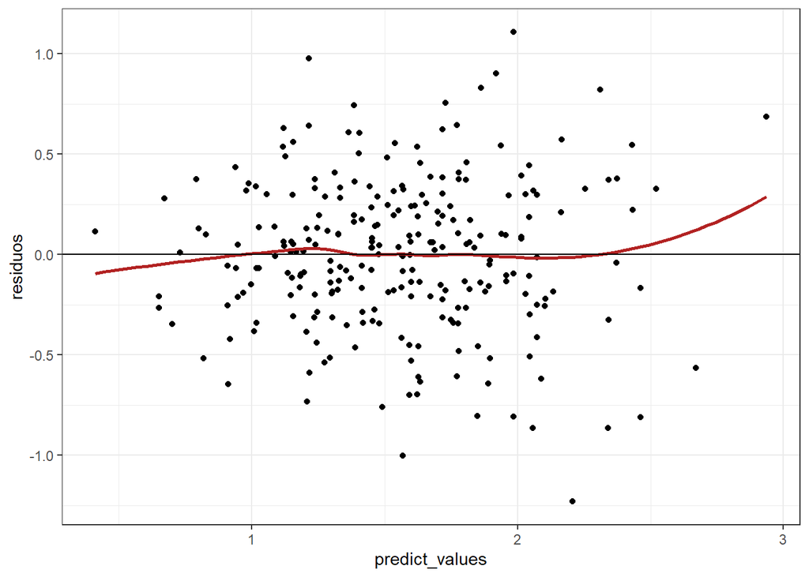

```r
ggplot(data = data.frame(predict_values = predict(ModelF),
                         residuos = residuals(ModelF)),
       aes(x = predict_values, y = residuos)) +
    geom_point() +
    geom_smooth(color = "firebrick", se = FALSE) +
    geom_hline(yintercept = 0) +
    theme_bw()
```

Se satisface la variabilidad constante

## 6.4 Predicción

```r
cont = 0
prediccion.NF <- 0:50
prediccion.FP <- 0:50
prediccion.NI <- 0:50
prediccion.FL <- 0:50
prediccion.FM <- 0:50
prediccion.FI <- 0:50

for (i in 30:81) {
  NF <- data.frame(edad=i, Tipo="NF", genero="M")
  FP <- data.frame(edad=i, Tipo="FP", genero="M")
  NI <- data.frame(edad=i, Tipo="NI", genero="M")
  FL <- data.frame(edad=i, Tipo="FL", genero="M")
  FM <- data.frame(edad=i, Tipo="FM", genero="M")
  FI <- data.frame(edad=i, Tipo="FI", genero="M")
  prediccion.NF[cont]<- predict(object=ModelF, newdata=NF)
  prediccion.FP[cont]<- predict(object=ModelF, newdata=FP)
  prediccion.NI[cont]<- predict(object=ModelF, newdata=NI)
  prediccion.FL[cont]<- predict(object=ModelF, newdata=FL)
  prediccion.FM[cont]<- predict(object=ModelF, newdata=FM)
  prediccion.FI[cont]<- predict(object=ModelF, newdata=FI)
  cont = cont + 1
}

edad <- 30:80

tabla <- data.frame(edad,prediccion.NF,prediccion.FP,prediccion.NI,prediccion.FL,prediccion.FM,prediccion.FI); tabla
```

```
##    edad prediccion.NF prediccion.FP prediccion.NI prediccion.FL prediccion.FM
## 1    30      2.521990     2.1053441     2.1184751     2.1301115     1.8325736
## 2    31      2.492258     2.0756123     2.0887432     2.1003796     1.8028417
## 3    32      2.462526     2.0458804     2.0590113     2.0706478     1.7731099
## 4    33      2.432794     2.0161485     2.0292795     2.0409159     1.7433780
## 5    34      2.403062     1.9864166     1.9995476     2.0111840     1.7136461
## 6    35      2.373331     1.9566848     1.9698157     1.9814521     1.6839142
## 7    36      2.343599     1.9269529     1.9400838     1.9517203     1.6541824
## 8    37      2.313867     1.8972210     1.9103520     1.9219884     1.6244505
## 9    38      2.284135     1.8674891     1.8806201     1.8922565     1.5947186
## 10   39      2.254403     1.8377573     1.8508882     1.8625246     1.5649867
## 11   40      2.224671     1.8080254     1.8211563     1.8327928     1.5352549
## 12   41      2.194939     1.7782935     1.7914245     1.8030609     1.5055230
## 13   42      2.165207     1.7485616     1.7616926     1.7733290     1.4757911
## 14   43      2.135476     1.7188298     1.7319607     1.7435971     1.4460592
```

[output cut: 89 more lines]

Y visto de manera grafica la tabla anterior con las predicciones

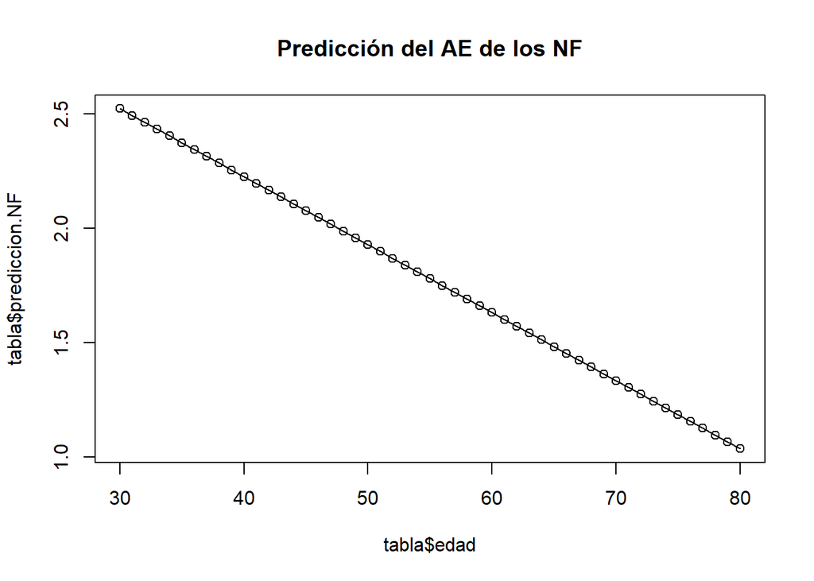

```r
plot(tabla$edad, tabla$prediccion.NF, type = "o", main = "Predicción del AE de los NF")
```

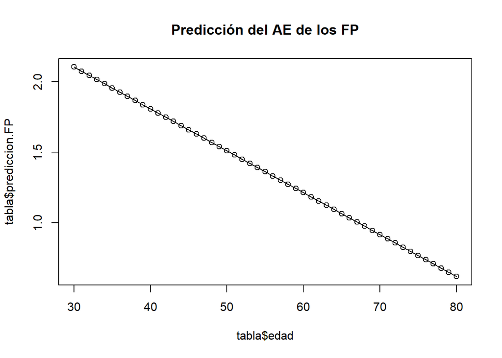

```r
plot(tabla$edad, tabla$prediccion.FP, type = "o", main = "Predicción del AE de los FP")
```

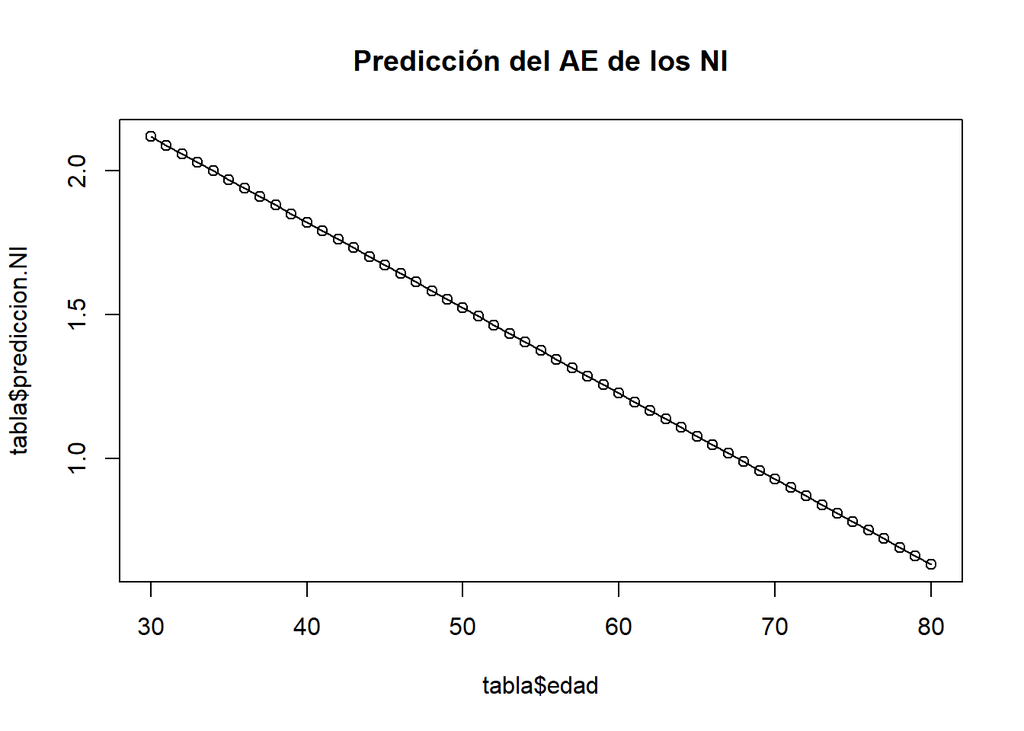

```r
plot(tabla$edad, tabla$prediccion.NI, type = "o", main = "Predicción del AE de los NI")
```

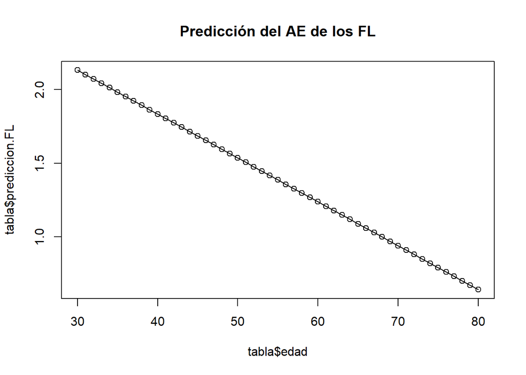

```r
plot(tabla$edad, tabla$prediccion.FL, type = "o", main = "Predicción del AE de los FL")
```

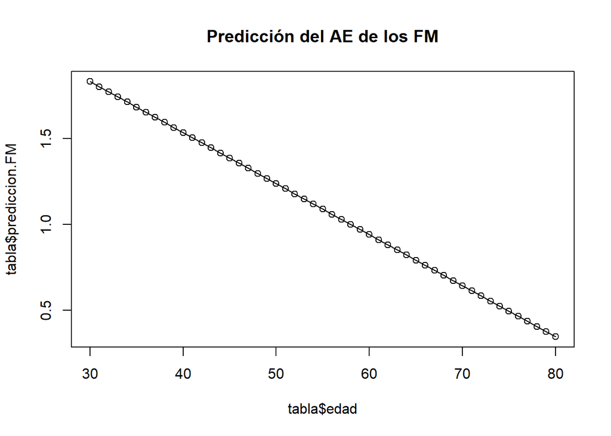

```r
plot(tabla$edad, tabla$prediccion.FM, type = "o", main = "Predicción del AE de los FM")
```

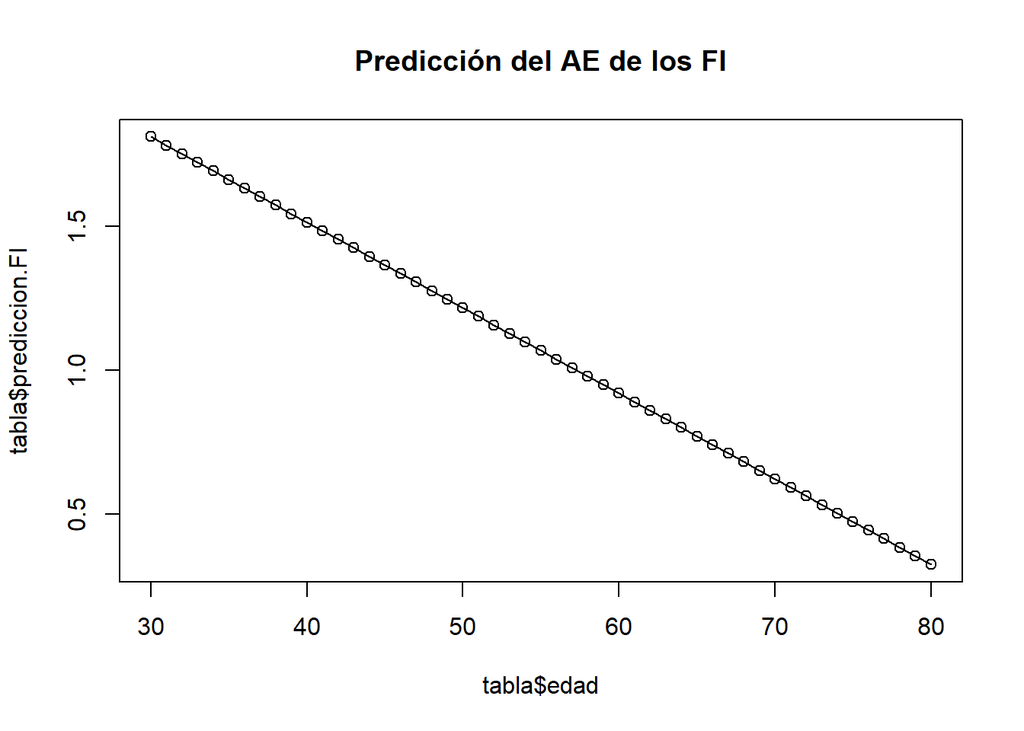

```r
plot(tabla$edad, tabla$prediccion.FI, type = "o", main = "Predicción del AE de los FI")
```

# 7 ANOVA unifactorial

## 7.1 Normalidad

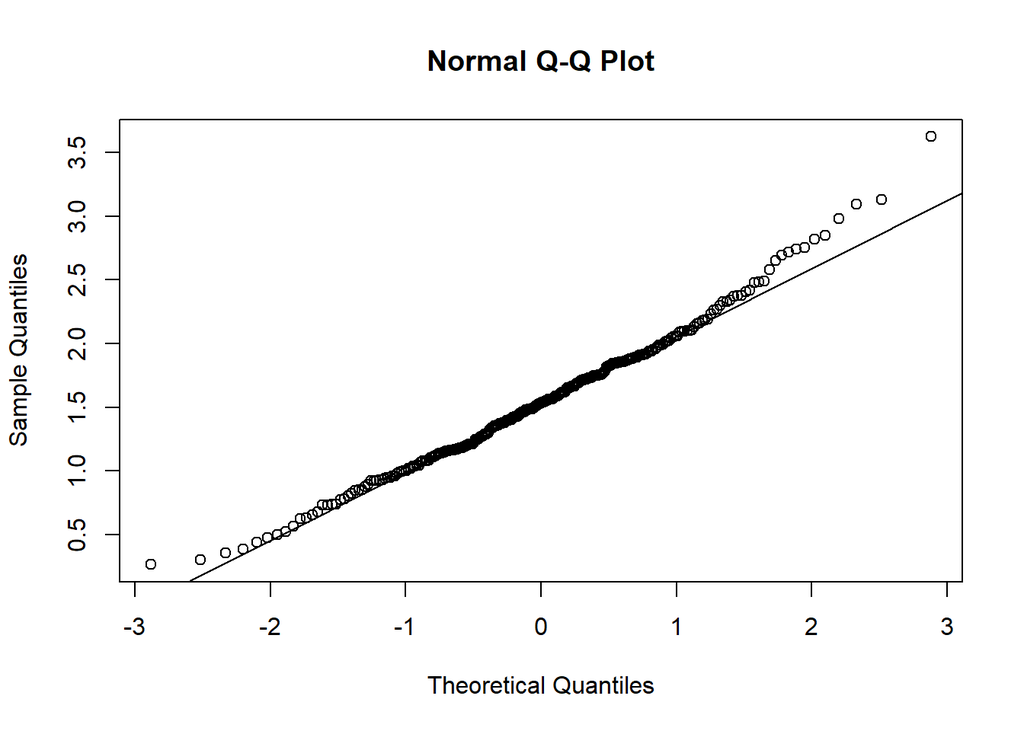

```r
qqnorm(datos$AE)
qqline(datos$AE)
```

```r
shapiro.test(datos$AE)
```

```
##
##  Shapiro-Wilk normality test
##
## data:  datos$AE
## W = 0.98869, p-value = 0.04484
```

El test de Shapiro indica que tenemos evidencia suficiente para rechazar la hipótesis nula al tener un p-value inferior a 0.05, por lo tanto la variable AE no tiene una distribución normal

## 7.2 Homoscedasticidad: Homogeneidad de varianzas

```r
bartlett.test(datos$AE ~ datos$Tipo)
```

```
##
##  Bartlett test of homogeneity of variances
##
## data:  datos$AE by datos$Tipo
## Bartlett's K-squared = 2.7036, df = 5, p-value = 0.7456
```

El test de Bartlett indica que no tenemos evidencia suficiente para rechazar la hipótesis nula (las varianzas son iguales) al tener un p-value superior a 0.05

## 7.3 Hipótesis nula y alternativa

H0 : AE_NF = AE_FP = AE_NI = AE_FL = AE_FM = AE_FI

H1 : AEi != AEj por algún i != j e i, j ∈ [AE_NF, AE_FP, AE_NI, AE_FL, AE_FM, AE_FI]

## 7.4 Cálculo ANOVA

```r
fm<- aov( lm(AE~Tipo, data=datos) )
summary(fm)
```

```
##              Df Sum Sq Mean Sq F value   Pr(>F)
## Tipo          5  21.16   4.232   18.23 2.15e-15 ***
## Residuals   247  57.33   0.232
## ---
## Signif. codes:  0 '***' 0.001 '**' 0.01 '*' 0.05 '.' 0.1 ' ' 1
```

## 7.5 Interpretación

Observamos que el valor del estadístico F es bastante mayor que la unidad hecho que indica que MSA > MSE y por tanto existe algún αi ̸= 0. De forma adicional, el valor p es claramente inferior a un nivel de significancia α del 5% y consecuentemente aceptamos la hipótesis alternativa para concluir que el factor Tipo es significativo.

## 7.6 Normalidad Residuos

Los gráficos y descriptivos nos informan si se verifica la igualdad de varianzas en los grupos descritos:

```r
summary(fm$residuals)
```

```
##      Min.   1st Qu.    Median      Mean   3rd Qu.      Max.
## -1.056251 -0.376784 -0.002166  0.000000  0.315957  1.630708
```

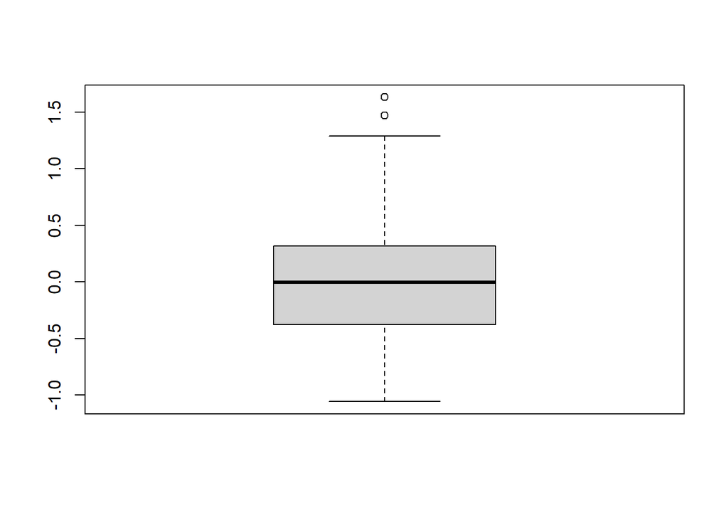

```r
boxplot(fm$residuals)
```

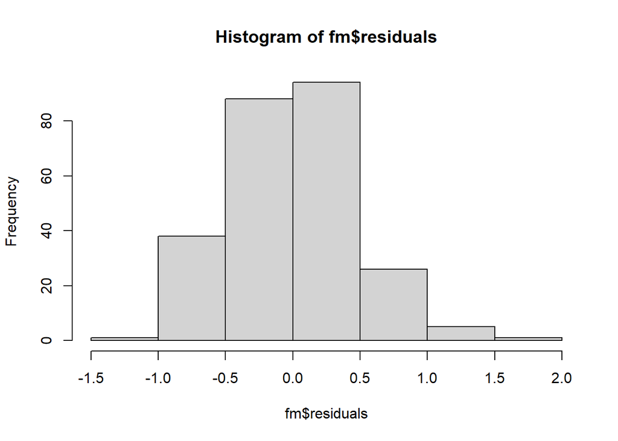

```r
hist(fm$residuals)
```

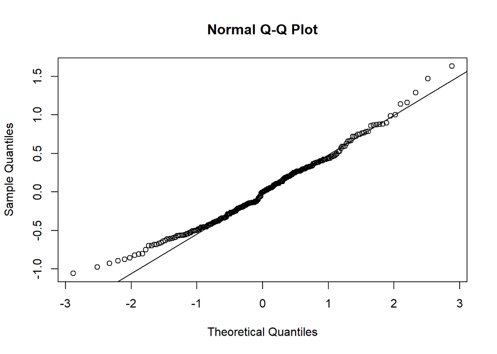

```r
qqnorm(fm$residuals)
qqline(fm$residuals)
```

```r
shapiro.test(fm$residuals)
```

```
##
##  Shapiro-Wilk normality test
##
## data:  fm$residuals
## W = 0.98504, p-value = 0.009426
```

## 7.7 Homoscedasticidad: Homogeneidad de varianzas de los Residuos

Los gráficos y descriptivos nos informan si se verifica la igualdad de varianzas en los grupos descritos:

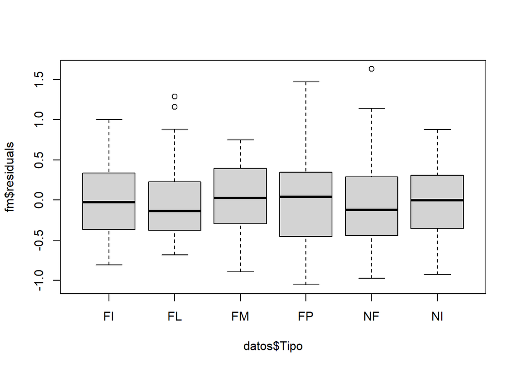

```r
boxplot(fm$residuals~datos$Tipo)
```

```r
desviaciones <- tapply(fm$residuals, datos$Tipo, sd)
max(desviaciones) / min(desviaciones)
```

```
## [1] 1.255941
```

Comparando la desviación máxima con la mínima obtenemos una orientación sobre que no falta homocedasticidad al no tener un valor superior a 2

```r
bartlett.test(fm$residuals ~ datos$Tipo)
```

```
##
##  Bartlett test of homogeneity of variances
##
## data:  fm$residuals by datos$Tipo
## Bartlett's K-squared = 2.7036, df = 5, p-value = 0.7456
```

El test de Bartlett indica que no tenemos evidencia suficiente para rechazar la hipótesis nula (las varianzas son iguales).

## 7.8 Profundizando en ANOVA

La suma de cuadrados totales:

```r
SSTotal <- var( datos$AE ) * (nrow(datos)-1)

cat("El valor del SST es:", SSTotal)
```

```
## El valor del SST es: 78.48591
```

Hacemos otra comprobación para saber que se ha calculado bien

```r
SS <- anova(fm)['Sum Sq']
SST <- sum(SS)
cat("El valor del SST es:", SST)
```

```
## El valor del SST es: 78.48591
```

El valor de SST mide la variabilidad en los datos asociada al efecto del factor sobre la media (la diferencia de las medias entre los diferentes niveles o grupos).

La Suma de Errores cuadrados de es:

```r
#Calculo SSW
SSW <- sum( fm$resid^2 )
cat("El valor del SSW es:", SSW)
```

```
## El valor del SSW es: 57.32743
```

```r
#Calulo SSB
SSB <- SSTotal - SSW
cat("El valor del SSB es:", SSB)
```

```
## El valor del SSB es: 21.15848
```

Bajo la Ho el estadístico de contraste F se distribuye como una F de grados de libertad (I-1), (n-I) donde I es el número de grupos que disponemos y n el tamaño total de la muestral. Así obtenemos el cuantil buscado:

```r
qf(0.05, 5-1, 16-5, lower.tail = F)
```

```
## [1] 3.35669
```

```r
dfE   <- fm$df.residual
dfReg <- nrow(datos) - 1 - dfE
MSreg <- SSB / dfReg
MSE   <- SSW / dfE
Fstat <- MSreg / MSE
pval  <- pf( Fstat , dfReg, dfE , lower.tail=FALSE )
cat("El valor de P-Value es:", pval)
```

```
## El valor de P-Value es: 2.145587e-15
```

## 7.9 Fuerza de la relación

```r
fuerza.relación <- SSB/ SST
fuerza.relación
```

```
## [1] 0.2695832
```

La fuerza de la relación representa que en 0.2695832 la variable Tipo tiene conocimiento de pertenenecia frente la variable AE.

# 8 Comparaciones múltiples

## 8.1 Test pairwise

```r
pairwise.t.test(datos$AE, datos$Tipo)
```

```
##
##  Pairwise comparisons using t tests with pooled SD
##
## data:  datos$AE and datos$Tipo
##
##    FI      FL      FM      FP      NF
## FL 0.01373 -       -       -       -
## FM 1.00000 0.00475 -       -       -
## FP 0.00096 1.00000 0.00021 -       -
## NF 5.9e-12 0.00019 2.3e-13 0.00150 -
## NI 0.00121 1.00000 0.00032 1.00000 0.00100
##
## P value adjustment method: holm
```

Del resultado podemos ver que hay varios valores p menor que 0.05, por lo tanto, concluiríamos que para esos casos hay una diferencia estadísticamente significativa en la capacidad pulmonar (AE) entre los encuestados de esos Tipos.

## 8.2 Corrección de Bonferroni

```r
pairwise.t.test(datos$AE, datos$Tipo , p.adj='bonferroni')
```

```
##
##  Pairwise comparisons using t tests with pooled SD
##
## data:  datos$AE and datos$Tipo
##
##    FI      FL      FM      FP      NF
## FL 0.04120 -       -       -       -
## FM 1.00000 0.01188 -       -       -
## FP 0.00144 1.00000 0.00027 -       -
## NF 6.4e-12 0.00021 2.3e-13 0.00322 -
## NI 0.00226 1.00000 0.00043 1.00000 0.00167
##
## P value adjustment method: bonferroni
```

Vemos que la corrección hace que los datos se alteren un poco (teniendo un valor mas alto), pero se sigue manteniendo los casos en donde existe una diferencia estadísticamente significativa en la capacidad pulmonar (AE) entre los encuestados de esos Tipos.

# 9 ANOVA multifactorial

## 9.1 Análisis visual

```r
mujeres <- datos_mujeres %>%  group_by(Tipo) %>%  summarise(media_AE = mean(AE))
mujeres$genero <- "F"
hombres <- datos_hombres %>%  group_by(Tipo) %>%  summarise(media_AE = mean(AE))
hombres$genero <- "M"
datos_media <- merge( mujeres, hombres, all = TRUE)
datos_media
```

```
##    Tipo media_AE genero
## 1    FI 1.126218      M
## 2    FI 1.238837      F
## 3    FL 1.524447      F
## 4    FL 1.556488      M
## 5    FM 1.073019      F
## 6    FM 1.266695      M
## 7    FP 1.612663      F
## 8    FP 1.628953      M
## 9    NF 1.933138      F
## 10   NF 2.066015      M
## 11   NI 1.602565      M
## 12   NI 1.610140      F
```

Visto de una manera grafica:

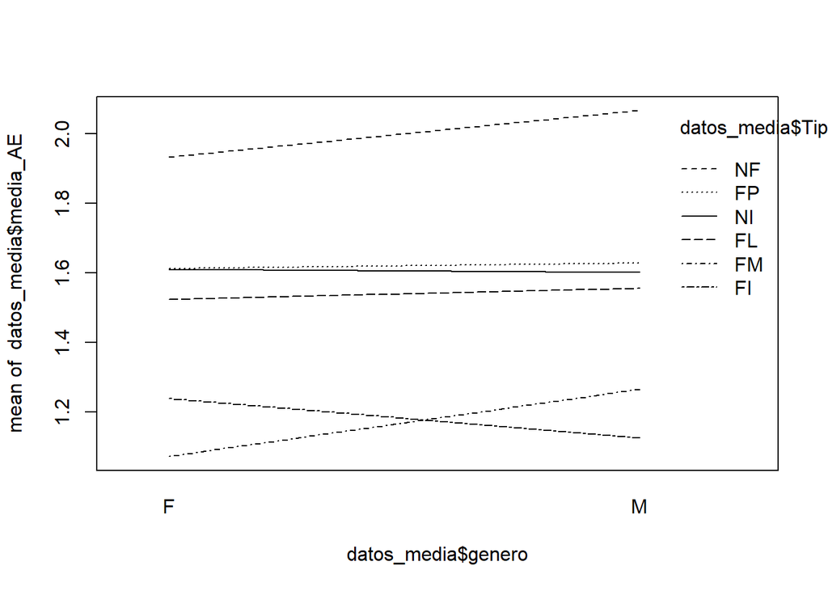

```r
interaction.plot(datos_media$genero,datos_media$Tipo,datos_media$media_AE)
```

## 9.2 ANOVA multifactorial

```r
mod_m <- aov(AE~genero*Tipo, data = datos)
anova(mod_m)
```

```
## Analysis of Variance Table
##
## Response: AE
##              Df Sum Sq Mean Sq F value    Pr(>F)
## genero        1  0.227  0.2269  0.9660    0.3267
## Tipo          5 21.071  4.2141 17.9374 4.094e-15 ***
## genero:Tipo   5  0.569  0.1138  0.4845    0.7877
## Residuals   241 56.619  0.2349
## ---
## Signif. codes:  0 '***' 0.001 '**' 0.01 '*' 0.05 '.' 0.1 ' ' 1
```

## 9.3 Interpretación

Las medias por niveles de los factores e interacciones son las siguientes:

```r
model.tables(mod_m, type = "means")
```

```
## Tables of means
## Grand mean
##
## 1.549338
##
##  genero
##           F       M
##       1.523   1.584
## rep 144.000 109.000
##
##  Tipo
##         FI     FL     FM     FP     NF     NI
##      1.193  1.543  1.157  1.616  1.991  1.604
## rep 36.000 37.000 39.000 44.000 52.000 45.000
##
##  genero:Tipo
##       Tipo
## genero FI     FL     FM     FP     NF     NI
##    F    1.239  1.524  1.073  1.613  1.933  1.610
##    rep 21.000 27.000 22.000 21.000 29.000 24.000
##    M    1.126  1.556  1.267  1.629  2.066  1.603
##    rep 15.000 10.000 17.000 23.000 23.000 21.000
```

Los efectos de los principales factores y de las interacciones son:

```r
model.tables(mod_m, type = "effects")
```

```
## Tables of effects
##
##  genero
##             F         M
##      -0.02606   0.03442
## rep 144.00000 109.00000
##
##  Tipo
##          FI       FL      FM       FP      NF      NI
##     -0.3566 -0.00652 -0.3922  0.06628  0.4419  0.0551
## rep 36.0000 37.00000 39.0000 44.00000 52.0000 45.0000
##
##  genero:Tipo
##       Tipo
## genero FI     FL     FM     FP     NF     NI
##    F    0.067  0.004 -0.064  0.017 -0.038  0.026
##    rep 21.000 27.000 22.000 21.000 29.000 24.000
##    M   -0.094 -0.012  0.082 -0.015  0.047 -0.030
##    rep 15.000 10.000 17.000 23.000 23.000 21.000
```

```r
HSD.test(mod_m, "genero", console = TRUE)
```

```
##
## Study: mod_m ~ "genero"
##
## HSD Test for AE
##
## Mean Square Error:  0.2349345
##
## genero,  means
##
##         AE       std   r      Min      Max
## F 1.523280 0.5758239 144 0.300825 3.622618
## M 1.583762 0.5344087 109 0.264860 2.849907
##
## Alpha: 0.05 ; DF Error: 241
## Critical Value of Studentized Range: 2.785797
##
## Groups according to probability of means differences and alpha level( 0.05 )
##
## Treatments with the same letter are not significantly different.
##
##         AE groups
## M 1.583762      a
## F 1.523280      a
```

Observamos que los niveles M y F son significativamente poco diferentes entre sí y por tanto forman un solo grupo (a).

Ahora haremos la comparación con la variable Tipo:

```r
HSD.test(mod_m, "Tipo", console = TRUE)
```

```
##
## Study: mod_m ~ "Tipo"
##
## HSD Test for AE
##
## Mean Square Error:  0.2349345
##
## Tipo,  means
##
##          AE       std  r      Min      Max
## FI 1.191913 0.4780196 36 0.386250 2.192456
## FL 1.533107 0.4863639 37 0.849617 2.820008
## FM 1.157442 0.4210978 39 0.264860 1.907640
## FP 1.621178 0.5022572 44 0.564927 3.091920
## NF 1.991910 0.5288741 52 1.016106 3.622618
## NI 1.606605 0.4513458 45 0.678176 2.483320
##
## Alpha: 0.05 ; DF Error: 241
## Critical Value of Studentized Range: 4.062744
##
## Groups according to probability of means differences and alpha level( 0.05 )
##
## Treatments with the same letter are not significantly different.
##
##          AE groups
## NF 1.991910      a
## FP 1.621178      b
## NI 1.606605      b
## FL 1.533107      b
## FI 1.191913      c
## FM 1.157442      c
```

Observamos un primer grupo solo con el nivel NF, por otro lado los niveles FP, NI, FL son significativamente poco diferentes entre sí y por tanto forman un grupo (b), mientras que si son significativamente diferentes con el nivel FI y FM que entre si forman otro grupo (c) y con el grupo anterior (a).

```r
inter <- with(datos, interaction(genero, Tipo))
mod_m_i<-aov(AE~inter, data = datos)
HSD.test(mod_m_i, "inter", console = TRUE)
```

```
##
## Study: mod_m_i ~ "inter"
##
## HSD Test for AE
##
## Mean Square Error:  0.2349345
##
## inter,  means
##
##            AE       std  r      Min      Max
## F.FI 1.238837 0.4816862 21 0.497211 2.192456
## F.FL 1.524447 0.4898074 27 0.849617 2.820008
## F.FM 1.073019 0.4036726 22 0.300825 1.684393
## F.FP 1.612663 0.6237722 21 0.564927 3.091920
## F.NF 1.933138 0.5769127 29 1.016106 3.622618
## F.NI 1.610140 0.4488733 24 0.732528 2.483320
## M.FI 1.126218 0.4815294 15 0.386250 2.088198
## M.FL 1.556488 0.5022849 10 1.004136 2.690880
## M.FM 1.266695 0.4298686 17 0.264860 1.907640
## M.FP 1.628953 0.3731033 23 1.069380 2.342200
## M.NF 2.066015 0.4631624 23 1.379952 2.849907
## M.NI 1.602565 0.4652162 21 0.678176 2.375820
##
## Alpha: 0.05 ; DF Error: 241
## Critical Value of Studentized Range: 4.667668
##
## Groups according to probability of means differences and alpha level( 0.05 )
##
## Treatments with the same letter are not significantly different.
##
##            AE groups
## M.NF 2.066015      a
## F.NF 1.933138     ab
## M.FP 1.628953    abc
## F.FP 1.612663    abc
## F.NI 1.610140    abc
## M.NI 1.602565    abc
## M.FL 1.556488   abcd
## F.FL 1.524447    bcd
## M.FM 1.266695     cd
## F.FI 1.238837     cd
## M.FI 1.126218     cd
## F.FM 1.073019      d
```

Observamos que el HSD test detecta 4 grupos no homogéneos (a,b,c y d).

Ahora veremos la adecuación del modelo ANOVA obtenido utilizando los gráficos de los residuos:

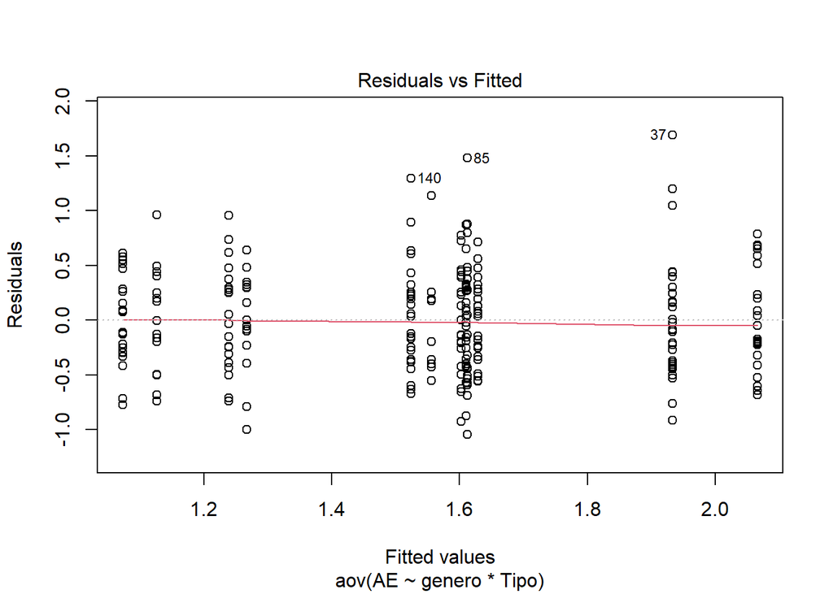

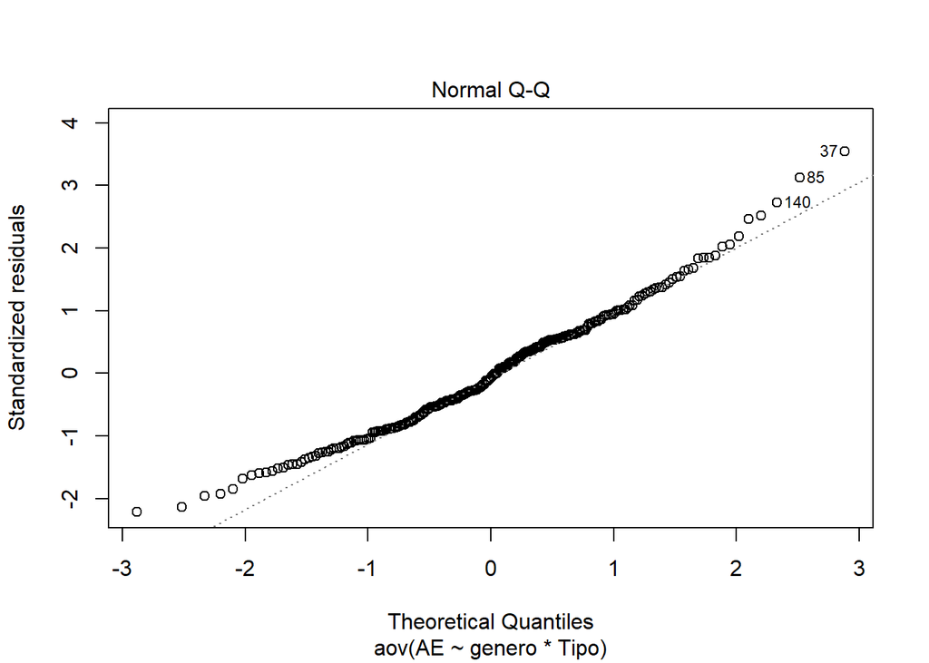

```r
plot(mod_m, which = c(1,2))
```

Analizamos la normalidad de los residuos con el test de Shapiro-Wilk

```r
shapiro.test(residuals(mod_m))
```

```
##
##  Shapiro-Wilk normality test
##
## data:  residuals(mod_m)
## W = 0.98453, p-value = 0.007645
```

Obtenemos un valor p pequeño (inferior a 0.05), rechazamos la hipótesis nula en favor de la alternativa y podemos decir que la distribución no es normal, por tanto el modelo anova no es adecuado.

# 10 Resumen técnico

[output not shown]

# 11 Resumen ejecutivo

En este estudio sobre la base de datos que contenía 4 variables principales: Capacidad Pulmonar (AE), Edad, Tipo de fumador y genero se ha realizado diferentes análisis de lo que cabe destacar la siguientes conclusiones:

Tras realizar distintos cálculos para obtener el intervalo de confianza de la capacidad pulmonar, se ha visto que no hay diferencias significativa en la capacidad pulmonar de los hombres y de las mujeres.

Para contrastar el resultado anterior, se ha hecho un contraste de hipótesis en donde la hipótesis nula es que la capacidad pulmonar es igual en hombres y mujeres, mientras que en la hipótesis alternativa esta capacidad es distinta. El resultado del contraste de hipótesis ha sido el mismo que en del intervalo de confianza, no existiendo diferencia en la capacidad pulmonar.

Siguiendo con el contraste de hipótesis, se ha querido realizar una comparación entre los tipos de fumadores, dividiéndolos en No fumadores (No fumadores y fumadores pasivos) y fumadores (resto de tipos). El resultado ha sido que la capacidad pulmonar de los fumadores es menor de los que no lo son.

Cambiando de modelo de análisis, se ha creado un modelo de regresión lineal para investigar la relación de la capacidad pulmonar con el resto de las variables. El modelo ha obtenido un coeficiente de determinación del 0,54. Aunque el coeficiente no es muy alto, si nos damos cuenta de que los No Fumadores son los que más hacen aumentar la capacidad pulmonar, y que, con el aumento de la edad, esta capacidad disminuye. Esta ultima afirmación se ha confirmado en la predicción del modelo, creando una predicción por cada tipo, de un sujeto masculino y por cada año contemplado entre los 30 y los 80 años.